```python
import numpy as np
import matplotlib
import matplotlib.pyplot as plt
import scipy
from scipy import stats
```

# Homework 2

## Q1:

Rolling sevens is more probable.  
Rolling snake eyes --> 1/36  
Rolling sevens --> 1/6

## Q2:

Analytically:  
I can draw out the charts including the sum of the two dices and count. Therefore, I get:

| Sum | 2 | 3 | 4 | 5 | 6 | 7 | 8 | 9 | 10 | 11 | 12 |
| --- | --- | --- | --- | --- | --- | --- | --- | --- | --- | --- | --- |
| Probability | 1/36 | 2/36 | 3/36 | 4/36 | 5/36 | 6/36 | 5/36 | 4/36 | 3/36 | 2/36 | 1/36 |

Numerically:

```python
probabilityArray = [1/6, 1/6, 1/6, 1/6, 1/6, 1/6]
probability = np.convolve(probabilityArray, probabilityArray)
print(probability)
```

```
[0.02777778 0.05555556 0.08333333 0.11111111 0.13888889 0.16666667
 0.13888889 0.11111111 0.08333333 0.05555556 0.02777778]
```

## Q3:

```python
mean = sum([2,3,4,5,6,7,8,9,10,11,12] * probability)
print("mean:")
print(mean)
```

```
mean:
7.0
```

```python
array = [2,3,4,5,6,7,8,9,10,11,12]
variance = sum((array - mean)**2 * probability)
print("variance:")
print(variance)
```

```
variance:
5.833333333333334
```

## Q4:

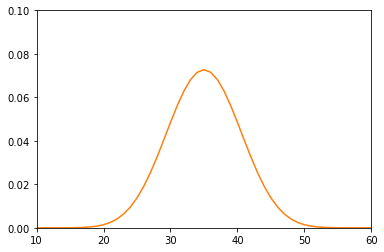

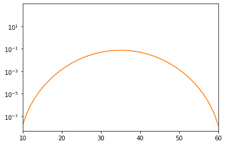

```python
a = 0
pr = [1/6, 1/6, 1/6, 1/6, 1/6, 1/6]
while a < 9:
    pr = np.convolve([1/6, 1/6, 1/6, 1/6, 1/6, 1/6], pr)
    a = a + 1
x = np.linspace(10, 60, len(pr))
fig, ax = plt.subplots()
ax.hist(pr, len(pr), density = True)
ax.plot(x, pr)
plt.xlim(10, 60)
plt.ylim(0, 0.1)

fig, ax = plt.subplots()
ax.hist(pr, len(pr), density = True)
ax.plot(x, pr)
plt.xlim(10, 60)
plt.yscale('log')
```

This looks like a Gaussian distribution. It is pretty normal and no skewed. Furthermore, I log the distribution and it follows a parabolic distribution.

## Q5:

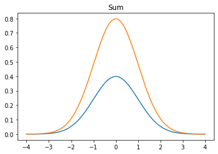

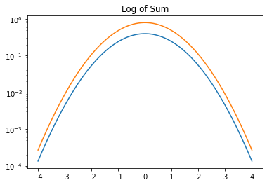

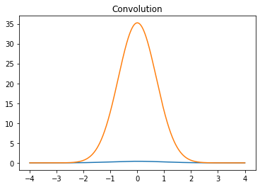

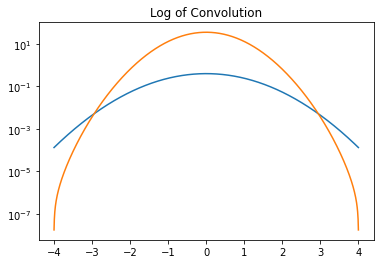

```python
d = stats.norm()
x = np.linspace(-4,4,1000)
fig, ax = plt.subplots()
plt.title('Sum')
ax.plot(x, d.pdf(x))
ax.plot(x, d.pdf(x) + d.pdf(x))

fig, ax = plt.subplots()
plt.title('Log of Sum')
plt.yscale('log')
ax.plot(x, d.pdf(x))
ax.plot(x, d.pdf(x) + d.pdf(x))

fig, ax = plt.subplots()
plt.title('Convolution')
ax.plot(x, d.pdf(x))
convolution = np.convolve(d.pdf(x), d.pdf(x))
ax.plot(np.linspace(-4,4,len(convolution)), convolution)

fig, ax = plt.subplots()
plt.title('Log of Convolution')
plt.yscale('log')
ax.plot(x, d.pdf(x))
convolution = np.convolve(d.pdf(x), d.pdf(x))
ax.plot(np.linspace(-4,4,len(convolution)), convolution)
```

As you can see from the graphs, blue line represents an initially Gaussian distribution and orange line represents the sum/convoluted of two initially Gaussian distribution. From the first graph "Sum," you can see that both follows the same curvature and same mean/variance. Therefore, sum of two Gaussian distribution is also Gaussian. I log the sum of Gaussian and it does follow the parabolic distribution. For the graph "Convolution," the blue line is the initially Gaussian distribution and as you can see, the orange distribution is also a Gaussian distribution. I log it and it is also parabolic distribution.

Therefore, I can conclude that the sum and average of an initially Gaussian distribution is also a Gaussian distribution.

The standard deviation doesn't change for the resulting sum Gaussian change, but it does change for resulting average Gaussian change as the curve shrinks. Therefore, by averaging the signal, one can simply decrease the standard deviation.